# HW1

Colin Flaherty

```r
library(tidyverse)
```

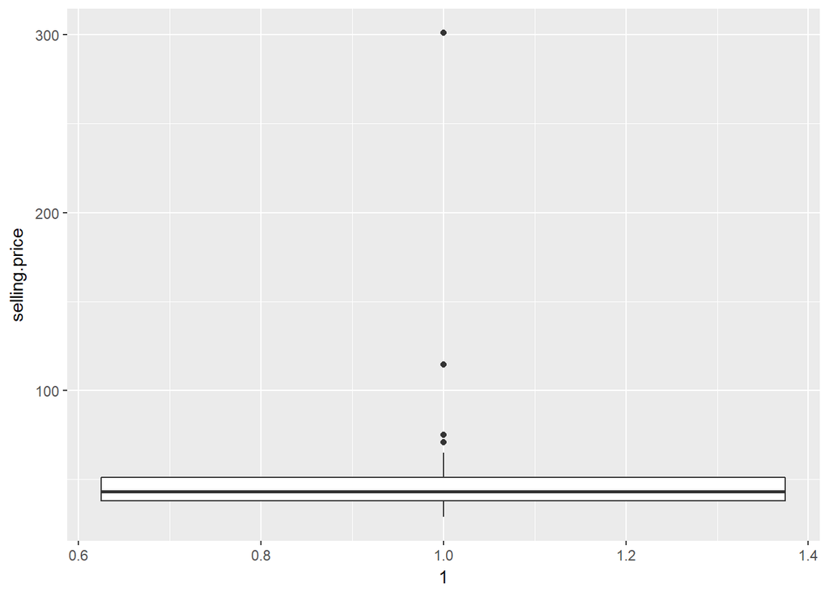

```r
library(ggplot2)
Mario.Kart <- read.csv(file="Mario Kart.csv", header=TRUE, sep=",")

Mario.Kart.clean <- Mario.Kart %>%
  mutate(selling.price = (totalPr- shipPr))

Mario.Kart.Box.Plot <-Mario.Kart.clean %>%
  ggplot(mapping = aes(x = 1, y = selling.price)) +
  geom_boxplot()

plot(Mario.Kart.Box.Plot)
```

```r
fivenum(Mario.Kart.clean$selling.price, na.rm = TRUE)
```

```
## [1]  28.980  37.995  43.000  51.000 301.000
```

The selling price is equal to the total price paid, minus the price paid for shipping. I added a column to the data set displaying this quantity, then created a boxplot displaying the distribution of this quantity among all entries in the data set, and printed the 5 number summary. From this, we see the minimun selling price is $28.98, and the maximum $301.00. The median selling price is $43.00, and values at 1st and 3rd quartiles are $37.995, and $51.00, respectively. We also see several outliers. This suggests an upward skew to the data set, and to further investigate the outliers.

```r
#Mario.Kart.clean %>%
# arrange(desc(selling.price))
```

On the boxplot from (1) we see 4 outliers. The 2 most expensive observations in the data set both include items other than the game and wii wheels. The most expensive sale included a wii console and Guitar Hero, and the second most expensive included 9 other games. Therefore we should discount these 2 most expensive outliers. The other 2 outliers have no information to suggest they are illegitimate data, so we should not exclude these observations.

```r
Mario.Kart.clean %>%
  group_by(wheels) %>%
  summarize(mean.total.price = mean(totalPr))
```

```
## # A tibble: 5 x 2
##   wheels mean.total.price
##    <int>            <dbl>
## 1      0             41.1
## 2      1             44.2
## 3      2             61.0
## 4      3             69.8
## 5      4             65.0
```

```r
#Mario.Kart.clean %>%
  #ggplot(aes(x= wheels, y = mean(Mario.Kart.clean$totalPr))) +
  #geom_bar(stat = "identity")
```

The above table shows that the mean total price increases as the number of included wheels increases up to 3 wheels. When the number of wii wheels increases from 3 to 4, the mean total price decreases.

```r
Mario.Kart.clean %>%
  filter(wheels == 3)
```

```
##     X           ID duration nBids cond startPr shipPr totalPr   shipSp
## 1  69 360193279993        7    12 used    0.99      4    64.5 standard
## 2 115 350261016626        1     3  new   69.95      0    75.0 standard
##   sellerRate stockPhoto wheels
## 1        991         no      3
## 2     118345        yes      3
##                                                    title selling.price
## 1   Wii  MARIO KART GAME  PLUS 3 STEERING WHEELS!   Wii           60.5
## 2 NEW MARIO KART WITH WII WHEEL+2 GT PRO WHITE WII WHEEL          75.0
```

```r
Mario.Kart.clean %>%
  filter(wheels == 4)
```

```
##    X           ID duration nBids cond startPr shipPr totalPr shipSp
## 1 84 160366174782        7     2 used      55   9.02   65.02 parcel
##   sellerRate stockPhoto wheels                                title
## 1         25         no      4 Mario Kart Wii (Wii) + 4 nerf wheels
##   selling.price
## 1            56
```

However, from the above we can see that there were only 2 listings with 3 wheels, and 1 listing with 4 wheels. Conclusions drawn about the relationship between total price and number of wii wheels should bear this in mind. It would be unreasonable to conclude from this data that adding wii wheels to a listing will only increase that auction’s total price up to 3 wii wheels.

```r
Mario.Kart.clean %>%
    mutate(has.wheel = ifelse(test = wheels > 0, yes = "yes", no = "no" )) %>%
    group_by(has.wheel, cond) %>%
    summarize(median.selling.price = median(selling.price))
```

```
## # A tibble: 4 x 3
## # Groups:   has.wheel [?]
##   has.wheel cond  median.selling.price
##   <chr>     <fct>                <dbl>
## 1 no        new                   40.5
## 2 no        used                  35.0
## 3 yes       new                   51.0
## 4 yes       used                  42.0
```

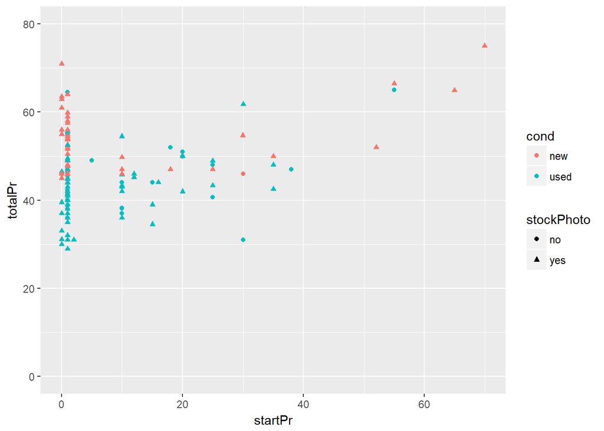

```r
Mario.Kart.clean %>%
  ggplot(aes(x = startPr, y = totalPr)) +
  geom_jitter(aes(color = cond, shape = stockPhoto)) +
  ylim(0, 80)
```

From the graph above we see a weak positive correlation between Starting Price and Total Price. As well, we can see that, in general, new items commanded a higher price than used items, and listings including a stock photo commanded a higher price than those that did not.

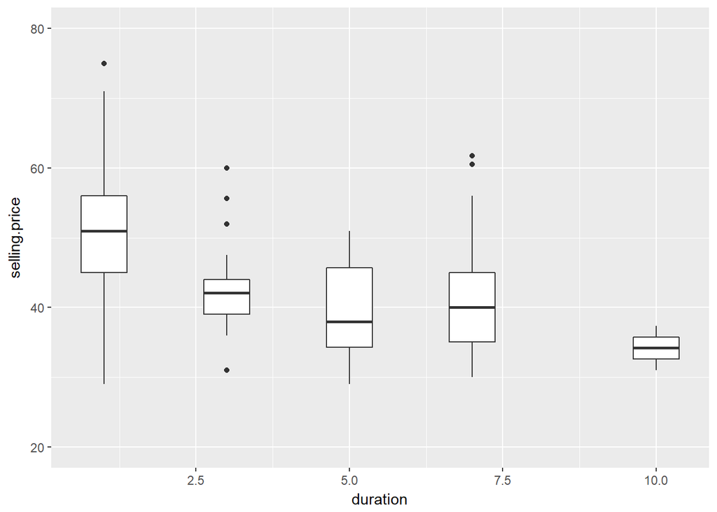

```r
Mario.Kart.clean %>%
  group_by(duration) %>%
  ggplot(aes(x = duration, y = selling.price)) +
  geom_boxplot(aes(group = duration)) +
  ylim(20, 80)
```

We see from above that as the auction duration increases, the median selling price tends to decrease. We also see that auctions that ended after 1 day have the largest range in selling price, and those that took 10 days to sell have a narrow range of selling prices. This may indicate a high demand for this item, as the “good” offers (perhaps those that are in good condition, or contain wii wheels) are bought quickly, despite demanding a higher price.

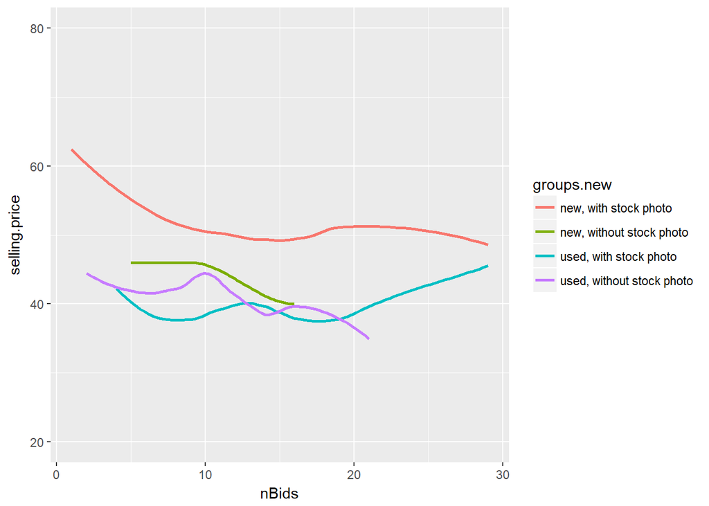

```r
Mario.Kart.clean.grouped <- Mario.Kart.clean%>%
  mutate(groups.new = ifelse(cond == "new" & stockPhoto == "yes", "new, with stock photo", ifelse(cond == "used" & stockPhoto == "no", "used, without stock photo", ifelse(cond == "new" & stockPhoto == "no", "new, without stock photo", "used, with stock photo"))))

Mario.Kart.clean.grouped %>%
  group_by(groups.new) %>%
  ggplot(aes(x = nBids, y = selling.price)) +
  geom_smooth(se=FALSE, aes(group = groups.new, color = groups.new)) +
  ylim(20, 80)
```

For all groups except “used, with stock photo,” we see a weak negative correlation between number of bids and selling price. For the “used, with stock photo” group, we see a weak positive correlation. However, these relationships are not monotonic, suggesting the number of bids has little effect on the selling price, as there is no explanation for why bids increasing would decrease the selling price of a listing up to a point, then increase the price, then decrease the price again.

8. From question 3 we see a positive correlation between the number of wii wheels included and the price of the auction. Though in our data set we see a price decrease as the number of wii wheels increases from 3 to 4, I expect this is coincidental. I would prefer to sell on eBay a copy of Mario Kart with the most wii wheels possible.

From question 5 we see that items listed as new, including a stock photo, command a higher price than those that don’t. We also see that in general, items with a higher starting price sell for more than those with a lower starting price. I would prefer to sell a new copy, which includes a stock photo on eBay, and begin the auction at a higher price.

We see from question 6 that a shorter auction duration can yield a higher selling price. I would prefer to give my auction a shorter length.